# R Notebook

Inputs: fastq files

Completed on dada version 1.30 and phyloseq version 1.46.0

Basic steps:

STEPS

- Step 1: Getting the files ready
- Step 2: Quality assessment and filtering
  - Step 2.1: Filtering & Trimming Primers or low quality sections of data
  - Step 2.2: Checking quality after filtering
- Step 3: Dereplication step
- Step 4: Error rates
- STEP 5: Construct ASVS with `DADA2`
- Step 6: Make a sequence table and remove chimeras
- Step 7: Assign taxonomy
- Step 8: Load metadata
- Step 9: Assemble phyloseq objects

Optionally you can make a tree and add it to your phyloseq object. I don’t have a tree making step in this workflow, but just know it is an option.

Note that most of the code here is commented out, and I’ve saved the objects that were made using the `saveRDS` function. This way if I need to stop mid-way, I won’t lose my progress. I can then re-load the made object with the `readRDS` function. Several of these steps require significant computational capacity and you won’t want to have to re-run them every time because they take a lot of time to run.

```r
library(tidyverse)
library(readxl)
library(ggpubr)
library(phyloseq)
library(janitor)
library(dada2)
```

### set up file paths

First we set up the file path to where your fastq sequences are

```r
path <- "../data/data"

#check that your data files are listed in the path, if not, you probably set the file path wrong
list.files(path)
```

```
##    [1] "filtered"
##    [2] "SG001-G001_S1_L001_R1_001.fastq.gz"
##    [3] "SG001-G001_S1_L001_R2_001.fastq.gz"
##    [4] "SG002-G002_S2_L001_R1_001.fastq.gz"
##    [5] "SG002-G002_S2_L001_R2_001.fastq.gz"
##    [6] "SG003-G003_S3_L001_R1_001.fastq.gz"
##    [7] "SG003-G003_S3_L001_R2_001.fastq.gz"
##    [8] "SG004-G004_S4_L001_R1_001.fastq.gz"
##    [9] "SG004-G004_S4_L001_R2_001.fastq.gz"
##   [10] "SG005-G005_S5_L001_R1_001.fastq.gz"
##   [11] "SG005-G005_S5_L001_R2_001.fastq.gz"
##   [12] "SG006-G006_S6_L001_R1_001.fastq.gz"
##   [13] "SG006-G006_S6_L001_R2_001.fastq.gz"
##   [14] "SG007-G007_S7_L001_R1_001.fastq.gz"
##   [15] "SG007-G007_S7_L001_R2_001.fastq.gz"
```

[output cut: 1060 more lines]

Then, we have to tell R which samples are the forward reads and which samples are the reverse reads

```r
# Forward and reverse fastq filenames have format: SAMPLENAME_R1_001.fastq and SAMPLENAME_R2_001.fastq
fnFs <- sort(list.files(path, pattern="_R1_001.fastq", full.names = TRUE))
fnRs <- sort(list.files(path, pattern="_R2_001.fastq", full.names = TRUE))

# Extract sample names, assuming filenames have format: SAMPLENAME_XXX.fastq
sample.names <- sapply(strsplit(basename(fnFs), "_"), `[`, 1)
```

### Inspect read quality

Here were looking at the quality of our sequences. I have 500+ samples, so I’m only goign to look at the first 5 samples, but you can look at all the samples if you want to by removing the brackets `[1:5]`

Forward reads

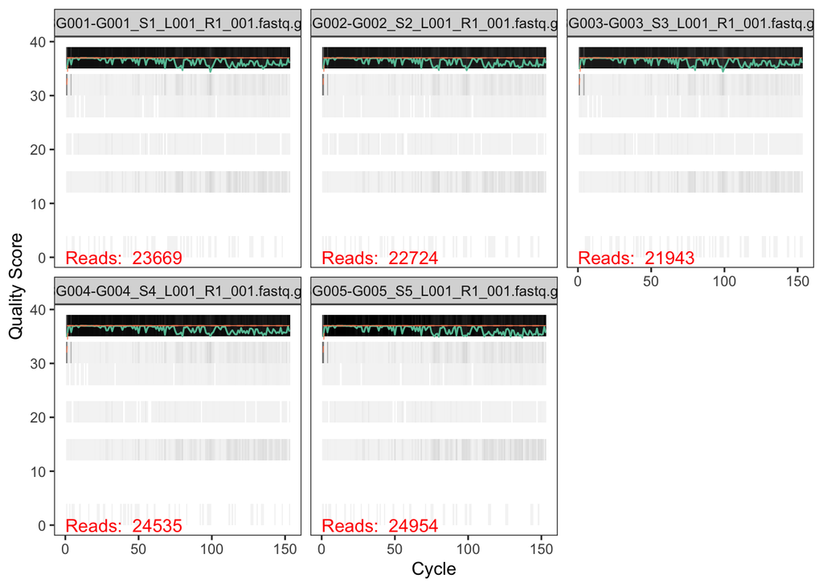

```r
plotQualityProfile(fnFs[1:5])
```

Reverse Reads

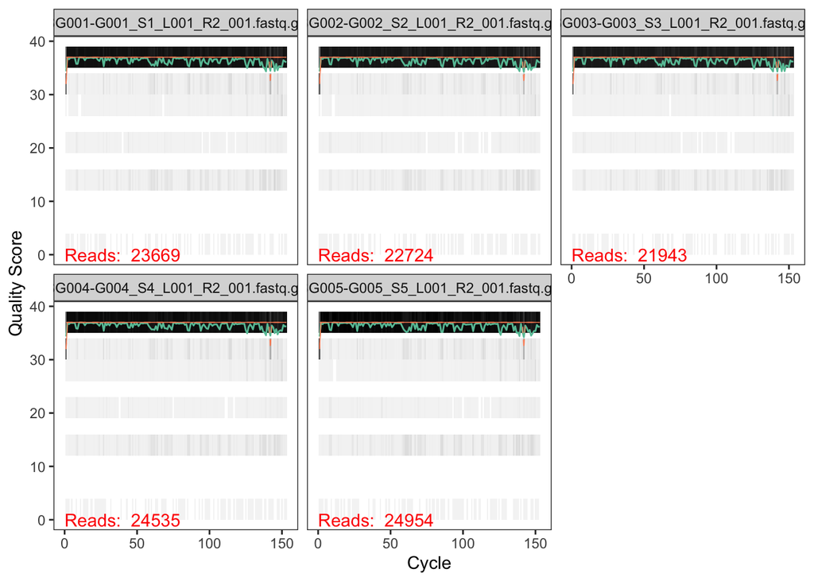

```r
plotQualityProfile(fnRs[1:5])
```

```r
# Place filtered files in filtered/ subdirectory
filtFs <- file.path(path, "filtered", paste0(sample.names, "_F_filt.fastq.gz"))
filtRs <- file.path(path, "filtered", paste0(sample.names, "_R_filt.fastq.gz"))
names(filtFs) <- sample.names
names(filtRs) <- sample.names
```

### Filter and Trim to remove primers and low quality reads

You will need to know what your primer sequences are so that you can trim them.

The primers for this project are 515F modified and 806R modified [Walters et al. 2016](https://journals.asm.org/doi/10.1128/msystems.00009-15?url_ver=Z39.88-2003&rfr_id=ori%3Arid%3Acrossref.org&rfr_dat=cr_pub++0pubmed)

515f Modified GTGYCAGCMGCCGCGGTAA 806r Modified GGACTACNVGGGTWTCTAAT

- trimLeft should be set to the lengths of the forward and reverse primers
- truncLen Truncate reads after trunLenc
  - It doesn’t look like we need to truncate ourreads at all. I’m not seeing anything that is super low quality

```r
#
# out <- filterAndTrim(fnFs, filtFs, fnRs, filtRs,
#                      #truncLen=c(150,150), #didn't truncate anything
#                      maxN=0,
#                      maxEE=c(2,2), #reads with higher than the expected number of errors will be discarded
#                      truncQ=2,
#                      rm.phix=TRUE,# remove phiX spike ins
#                      trimLeft=c(19,20), # remove primers
#                      compress=TRUE,
#                      multithread=TRUE) # On Windows set multithread=FALSE
# head(out)
#
#saveRDS(out, "output/out")

out <- readRDS("output/out")
```

Check filtered reads quality

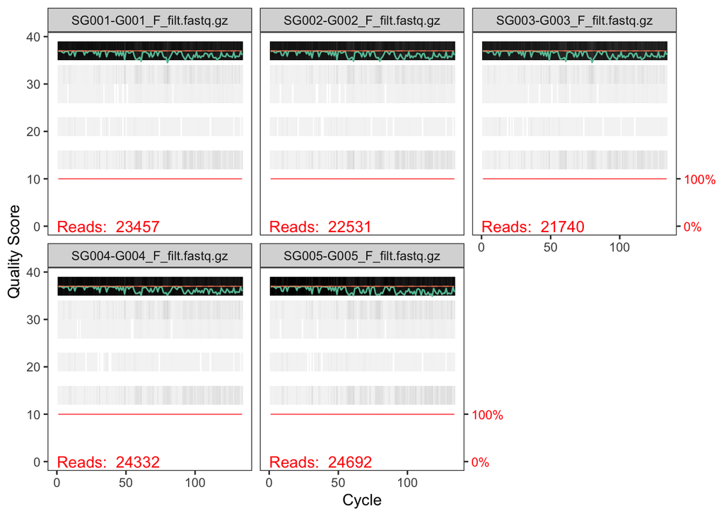

```r
plotQualityProfile(filtFs[1:5])
```

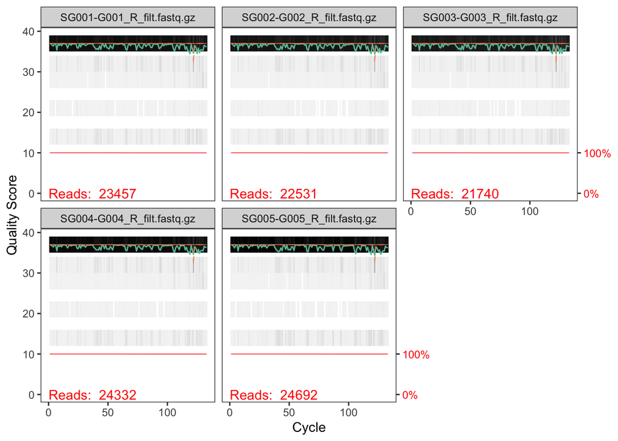

```r
plotQualityProfile(filtRs[1:5])
```

### Dereplication

> Dereplication combines all identical sequencing reads into into “unique sequences” with a corresponding “abundance” equal to the number of reads with that unique sequence. Dereplication substantially reduces computation time by eliminating redundant comparisons.

> Dereplication in the DADA2 pipeline has one crucial addition from other pipelines: DADA2 retains a summary of the quality information associated with each unique sequence. The consensus quality profile of a unique sequence is the average of the positional qualities from the dereplicated reads. These quality profiles inform the error model of the subsequent sample inference step, significantly increasing DADA2’s accuracy.

```r
# derepFs <- derepFastq(filtFs, verbose=TRUE)
# derepRs <- derepFastq(filtRs, verbose=TRUE)
# # Name the derep-class objects by the sample names
# names(derepFs) <- sample.names
# names(derepRs) <- sample.names

# saveRDS(derepFs, "output/derepFs")
# saveRDS(derepRs, "output/derepRs")
```

### Learn the Error Rates

```r
# errF <- learnErrors(derepFs, multithread=TRUE)
# errR <- learnErrors(derepRs, multithread=TRUE)
#
# saveRDS(errF, "output/errF")
# saveRDS(errR, "output/errR")

errF <- readRDS("output/errF")
errR <- readRDS("output/errR")
```

> The error rates for each possible transition (A→C, A→G, …) are shown. Points are the observed error rates for each consensus quality score. The black line shows the estimated error rates after convergence of the machine-learning algorithm. The red line shows the error rates expected under the nominal definition of the Q-score. * Estimated error rates (black line); observed rates (points)

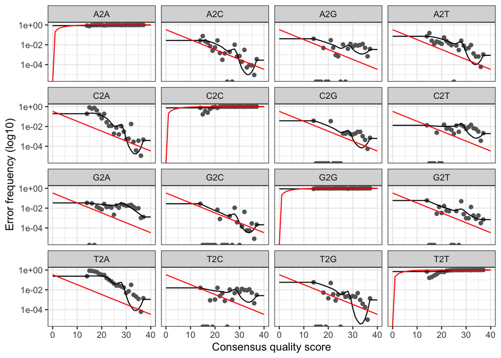

```r
plotErrors(errF, nominalQ=TRUE)
```

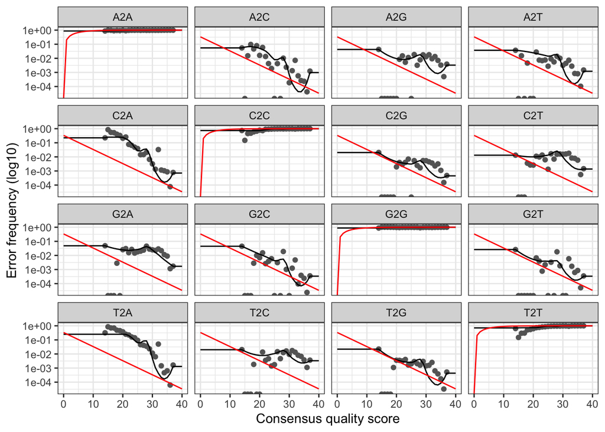

```r
plotErrors(errR, nominalQ = TRUE)
```

### Sample Inference

```r
# dadaFs <- dada(derepFs, err=errF, multithread=TRUE)
# dadaRs <- dada(derepRs, err=errR, multithread=TRUE)
#
# saveRDS(dadaFs, "output/dadaFs")
# saveRDS(dadaRs, "output/dadaRs")

dadaFs <- readRDS("output/dadaFs")
dadaRs <- readRDS("output/dadaRs")
```

```r
dadaFs[[1]]
```

```
## dada-class: object describing DADA2 denoising results
## 103 sequence variants were inferred from 4859 input unique sequences.
## Key parameters: OMEGA_A = 1e-40, OMEGA_C = 1e-40, BAND_SIZE = 16
```

```r
dadaRs[[1]]
```

```
## dada-class: object describing DADA2 denoising results
## 81 sequence variants were inferred from 5300 input unique sequences.
## Key parameters: OMEGA_A = 1e-40, OMEGA_C = 1e-40, BAND_SIZE = 16
```

### Merge paired reads

Now that we’re prepped our forward and reverse sequences, we can merge them together.

```r
# #
# mergers <- mergePairs(dadaFs, derepFs, dadaRs, derepRs, verbose=TRUE)
# # Inspect the merger data.frame from the first sample
# head(mergers[[1]])
# # #
#
# #
# saveRDS(mergers, "output/mergers")

mergers <- readRDS("output/mergers")
```

### Construct seq tab

Once we have our merged sequences, we construct a sequence table. The sequence table contains all of the unique 16S sequences and the counts for each of the sequences in each sample.

```r
# seqtab <- makeSequenceTable(mergers)
# dim(seqtab)
#
# saveRDS(seqtab, "output/seqtab")

seqtab <- readRDS("output/seqtab")
```

> Considerations for your own data: Sequences that are much longer or shorter than expected may be the result of non-specific priming. You can remove non-target-length sequences from your sequence table (eg. seqtab2 <- seqtab[,nchar(colnames(seqtab)) %in% 250:256]). This is analogous to “cutting a band” in-silico to get amplicons of the targeted length. (dada2 tutorial)

```r
# Inspect distribution of sequence lengths
table(nchar(getSequences(seqtab)))
```

```
##
##  160  168  178  180  215  221  232  233  249  251  252  253  254  255
##   96    1    1    1    5    1    1    1    1    2 3502 7809  264   21
```

```r
#some sequences are shorter than expected. I am going to remove any sequences less than 250 bp

seqtab <- seqtab[,nchar(colnames(seqtab)) %in% 250:256]

#check sequences again after filtering
table(nchar(getSequences(seqtab)))
```

```
##
##  251  252  253  254  255
##    2 3502 7809  264   21
```

### Remove chimeras

> A sequencing chimera is a type of artifact that occurs during the process of DNA sequencing, specifically during the Polymerase Chain Reaction (PCR) amplification process. These chimeras are formed when two or more distinct DNA sequences are incorrectly joined together, producing a sequence that does not naturally exist in the organism being studied. (GPT -4o)

```r
#seqtab.nochim <- removeBimeraDenovo(seqtab, method="consensus", multithread=TRUE, verbose=TRUE)

#saveRDS(seqtab.nochim, "output/seqtab.nochim")

seqtab.nochim <- readRDS("output/seqtab.nochim")
```

### Track reads through pipeline

```r
#check number of reads that made it through each step of the pipeline

getN <- function(x) sum(getUniques(x))
track <- cbind(out, sapply(dadaFs, getN), sapply(dadaRs, getN), sapply(mergers, getN), rowSums(seqtab.nochim))
# If processing a single sample, remove the sapply calls: e.g. replace sapply(dadaFs, getN) with getN(dadaFs)
colnames(track) <- c("input", "filtered", "denoisedF", "denoisedR", "merged", "nonchim")
rownames(track) <- sample.names
head(track)
```

```
##            input filtered denoisedF denoisedR merged nonchim
## SG001-G001 23669    23457     23276     23324  22782   21220
## SG002-G002 22724    22531     22306     22372  21656   20173
## SG003-G003 21943    21740     21542     21624  20969   19117
## SG004-G004 24535    24332     24131     24155  23182   21927
## SG005-G005 24954    24692     24383     24532  23329   22278
## SG006-G006 18348    18212     18111     18149  17887   16361
```

### Assign Taxonomy

Now we have to assign taxonomy to all of the sequences. We’ll be using the Silva database.

You can download the database here:

[Silva v138.1 database](https://zenodo.org/records/4587955) downloaded on 11/1/2024

```r
# taxa <- assignTaxonomy(seqtab.nochim, "silva_nr99_v138.1_wSpecies_train_set.fa.gz", multithread=T)
#
# saveRDS(taxa, "output/taxa")

taxa <- readRDS("output/taxa")
```

```r
taxa.print <- taxa # Removing sequence rownames for display only
rownames(taxa.print) <- NULL
head(taxa.print)
```

```
##      Kingdom    Phylum              Class              Order
## [1,] "Bacteria" "Firmicutes"        "Bacilli"          "Erysipelotrichales"
## [2,] "Bacteria" "Verrucomicrobiota" "Verrucomicrobiae" "Verrucomicrobiales"
## [3,] "Bacteria" "Bacteroidota"      "Bacteroidia"      "Bacteroidales"
## [4,] "Bacteria" "Bacteroidota"      "Bacteroidia"      "Bacteroidales"
## [5,] "Bacteria" "Firmicutes"        "Bacilli"          "Lactobacillales"
## [6,] "Bacteria" "Actinobacteriota"  "Actinobacteria"   "Bifidobacteriales"
##      Family                Genus             Species
## [1,] "Erysipelotrichaceae" "Faecalibaculum"  "rodentium"
## [2,] "Akkermansiaceae"     "Akkermansia"     "muciniphila"
## [3,] "Muribaculaceae"      NA                NA
## [4,] "Muribaculaceae"      NA                NA
## [5,] "Lactobacillaceae"    "Lactobacillus"   "johnsonii"
## [6,] "Bifidobacteriaceae"  "Bifidobacterium" "pseudolongum"
```

### Make phyloseq object

Load metadata. The important thing is to make sure that the the rownames of the seqtab are identical to the rownames of the metadata

In my case, the rownames do not match with the sample_id [1] “SG001-G001” “SG002-G002” “SG003-G003” “SG004-G004” “SG005-G005” “SG006-G006” “SG007-G007” [1] “G0001” “G0002” “G0003” “G0004” “G0005” “G0006” “G0007”

Need to remove the SG… From the rownames, and then remove an extra 0 from the sample names

First load the metadata file

```r
# #load metadata
# meta_data <- meta.2
#
# # Remove one of the leading zeros from sample names
# meta_data$sample_id <- sub("G00(\\d)", "G0\\1", meta_data$sample_id)
#
# #save meta data to manually adjust the metadata to remove non-sequencing samples and add PCR negative samples
#write_csv(meta_data, "meta.csv")
#
```

Now make sure your sample ids match your seqtab rownames

```r
# Using sub() to replace everything up to and including the first "-"
rownames(seqtab.nochim) <- sub(".*-", "", rownames(seqtab.nochim))

meta.df <- read_csv("meta_edit2.csv")
meta.df <- as.data.frame(meta.df)

#make sample id the rownames for the metadata
rownames(meta.df) <- meta.df$sample_id

#see if there are differences between the two objects
#diff <- setdiff( rownames(meta.df), rownames(seqtab.nochim))
#diff <- setdiff( , rownames(seqtab.nochim), rownames(meta.df))


#check if identical
identical(rownames(seqtab.nochim), rownames(meta.df))
```

```
## [1] TRUE
```

Now we put all the pieces together in a phyloseq object: the seqtab, the metadata, and the taxa table

```r
#should be true
identical(colnames(seqtab.nochim), rownames(taxa))
```

```
## [1] TRUE
```

```r
ps <- phyloseq(otu_table(seqtab.nochim, taxa_are_rows=F),
               sample_data(meta.df),
               tax_table(taxa))

ps
```

```
## phyloseq-class experiment-level object
## otu_table()   OTU Table:         [ 1761 taxa and 537 samples ]
## sample_data() Sample Data:       [ 537 samples by 18 sample variables ]
## tax_table()   Taxonomy Table:    [ 1761 taxa by 7 taxonomic ranks ]
```

```r
#saveRDS(ps, "output/ps")
```